# Hypothesis testing

Statistical Inference II

Aldo Solari https://aldosolari.github.io/ (DEMS)http://dems.unimib.it/  
2019-07-07

# Darwin data

**Reference**: Davison (2003), Example 1.1

Charles Darwin collected data over a period of years on the heights of Zea mays plants. The plants were descended from the same parents and planted at the same time.

Half of the plants were *self-fertilized*, and half were *cross-fertilized*, and the purpose of the experiment was to compare their *heights*. To this end Darwin planted them in pairs in different pots.

```
   Pot  Cross   Self
1    I 23.500 17.375
2    I 12.000 20.375
3    I 21.000 20.000
4   II 22.000 20.000
5   II 19.125 18.375
6   II 21.500 18.625
7  III 22.125 18.625
8  III 20.375 15.250
9  III 18.250 16.500
10 III 21.625 18.000
11 III 23.250 16.250
12  IV 21.000 18.000
13  IV 22.125 12.750
14  IV 23.000 15.500
15  IV 12.000 18.000
```

Cross-fertilized plants seem higher than self-fertilized ones, with averages:

```
   type   height
1 Cross 20.19167
2  Self 17.57500
```

Questions arise:

1. Is the difference in heights too large to have occurred by chance?
2. Can we estimate the height increase, and assess the uncertainty of our estimate?

### Galton model

Galton considered a model where the height of a self-fertilized plant is
$$Y = \mu + \sigma \varepsilon$$
and of a cross-fertilized plant is
$$X = \mu + \theta + \sigma \epsilon$$
where $\mu$, $\theta$ and $\sigma$ are unknown parameters, and $\varepsilon$ and $\epsilon$ are independent random variables with mean zero and unit variance.

Observations from self-fertilized plants $Y_1,\ldots,Y_{15}$ are i.i.d. as $Y$, and observations from cross-fertilized plants $X_1,\ldots,X_{15}$ are i.i.d. as $X$.

Under this model the questions translate to:

1. Is the average height increase $\theta \neq 0$?
2. Can we estimate $\theta$, and assess the uncertainty of our estimate?

The comparison between groups can be visualized by a boxpot:

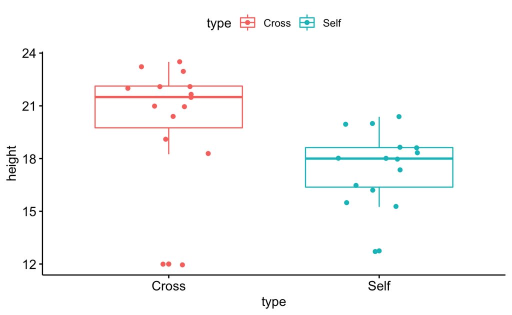

Figure 1: Darwin data: comparison of box-plots

If we assume that $\varepsilon$ and $\epsilon$ have a $N(0,1)$ distribution, we can use

```
    Two Sample t-test

data:  height by type
t = 2.4371, df = 28, p-value = 0.02141
alternative hypothesis: true difference in means is not equal to 0
95 percent confidence interval:
 0.4173433 4.8159900
sample estimates:
mean in group Cross  mean in group Self
           20.19167            17.57500
```

### Fisher model

In order to minimize differences in humidity, growing conditions, and lighting, Darwin had taken the trouble to plant the seeds in pairs in the same pots.

Comparison of different pairs would therefore involve these differences, which are not of interest, whereas *comparison within pairs* would depend only on the type of fertilization.

Fisher considered the model
$$Y_i = \mu_i + \sigma \varepsilon_{i}, \quad X_i = \mu_i + \theta + \sigma \epsilon_{i}, \quad i = 1,\ldots,n$$

The parameter $\mu_i$ represents the effects of the planting conditions for the $i$th pair, and $\varepsilon_i$ and $\epsilon_i$ are independent random variables with mean zero and unit variance.

The $\mu_i$ could be eliminated by using the differences
$$D_i = X_i - Y_i$$
which have mean $\theta$ and variance $2\sigma^2$.

The comparison within pairs can be visualized by the following plot:

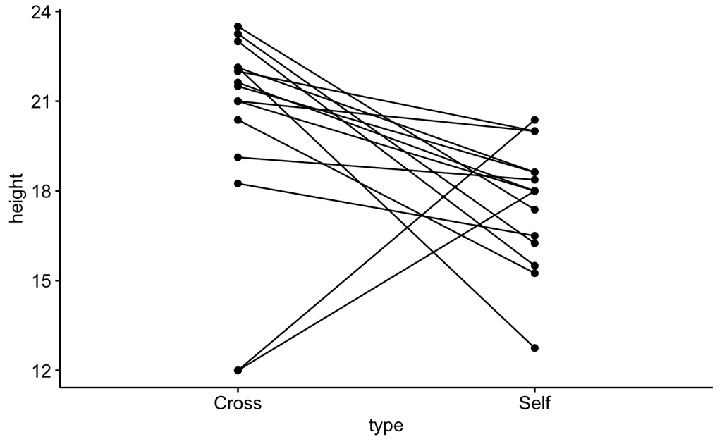

Figure 2: Darwin data: difference in height for each pair

If we assume that $D_1,\ldots,D_{15}$ are i.i.d. $N(\theta,2\sigma^2)$, we can use

```
    One Sample t-test

data:  differences
t = 2.148, df = 14, p-value = 0.0497
alternative hypothesis: true mean is not equal to 0
95 percent confidence interval:
 0.003899165 5.229434169
sample estimates:
mean of x
 2.616667
```

# $p$-values

**Reference**: Davison (2003), Section 7.3.1

A scientific theory leads to assertions that are testable using empirical data. One way to investigate the extent to which a theory is supported by the *data* $Y$ is to choose a *test statistic*, $T=t(Y)$, large values of which cast dubts on the theory.

This theory, the *null hypothesis* $H_0$, places restrictions on the distribution of $Y$ and is used to calculate a $p$-value
$$p_{\mathrm{obs}}=\mathrm{P}_{0}(T \geq t_{\mathrm{obs}})$$
where $t_{\mathrm{obs}}$ is the value of $T$ actually observed.

A distribution computed under the assumption that $H_0$ is true is called *null distribution*, and then we use $\mathrm{P}_{0}, \mathrm{E}_0$, $\ldots$ to indicate probability, expectation and so forth.

### $p$-value null distribution

The $p$-value may be written as $p_{\mathrm{obs}}=1 - F_0(t_{\mathrm{obs}})$, where $F_0$ is the null distribution function of $T$, supposed to be continuous.

One interpretation of $p_{\mathrm{obs}}$ stems from the correponding random variable $P=1-F_0(T)$. For $0 \leq u \leq 1$, its null distribution is *uniform* on the unit interval:
$$\mathrm{P}_{0}(P\leq u) = \mathrm{P}_{0}(F_0^{-1}(1-u)\leq T) = 1 - F_0(F_0^{-1}(1-u))=u$$

If we consider $t_{\mathrm{obs}}$ as just decisive evidence against $H_0$, then we would reject the hypothesis when true a long-run proportion $p_{\mathrm{obs}}$ of times.

### One- and two-sided tests

Suppose that we have a test statistic $T$, small and large values of which indicate a departure from $H_0$. The simplest procedure is then often to contemplate two tests, one for each tail.

With test statistic $T$, consider two $p$-values, namely
$$p^-_{\mathrm{obs}}=\mathrm{P}_{0}(T \leq t_{\mathrm{obs}}), \quad p^+_{\mathrm{obs}}=\mathrm{P}_{0}(T \geq t_{\mathrm{obs}})$$
and taking the smallest $p$-value multiplied by 2 when the distribution of $T$ is continous.

This follows because the null distribution of $Q = \min(P^-,P^+)$ is that of $\min(1-U,U)$ with $U$ uniform on $(0,1)$, i.e. uniform on $(0,\frac{1}{2})$ and the $p$-value is
$$p_{\mathrm{obs}} =\mathrm{P}_{0}(Q \leq q_{\mathrm{obs}}) = 2q_{\mathrm{obs}}$$

In a discrete problem it is $q_{\mathrm{obs}}$ plus the achievable $p$-value from the other tail of the distribution nearest to but not exceeding $q_{\mathrm{obs}}$.

### Nonparametric tests

Tests where the null hypotheses itself is formulated in terms of arbitrary distributions, so-called *nonparametric* or *distribution-free tests*.

A random sample $Y_1,\ldots,Y_n$ arises from an unknown continuous distribution $F$. The null hypothesis $H_0$ asserts that $F$ has median $\eta$ equal to $\eta_0$.

If $\eta = \eta_0$, the probability that $Y$ falls on either side of $\eta_0$ is $1/2$. This suggests that we can base a test on
$$T = \sum_{i=1}^{n}I\{Y_i > \eta_0\}$$

Under $H_0$, $T$ has a binomial distribution with size $n$ and probability $1/2$, so its mean and variance are $n/2$ and $n/4$. The one-sided $p$-values are

$$p^+_{\mathrm{obs}}= \mathrm{P}_0(T \geq t_{\mathrm{obs}}) = \sum_{k=t_{\mathrm{obs}}}^{n} {n \choose k}\frac{1}{2^n}, \quad p^-_{\mathrm{obs}} = \mathrm{P}_0(T \leq t_{\mathrm{obs}}) = \sum_{k=0}^{t_{\mathrm{obs}}} {n \choose k}\frac{1}{2^n}$$

Consider a more complicated matched pair model for the Darwin data, where the height differences may be written as
$$D_i = \theta + \sigma_i(\varepsilon_i - \epsilon_i)$$

If $\varepsilon_i-\epsilon_i$ are symmetrically distributed around zero, then $D_i$ are symmetrically distributed around $\theta$, i.e.
$$D_i - \theta \stackrel{d}{=} \theta - D_i \qquad i=1,\ldots,n$$

By testing $H_0:\theta=0$, we have $t_{\mathrm{obs}} = 13$ and a two-sided $p$-value of

```
    Exact binomial test

data:  13 and 15
number of successes = 13, number of trials = 15, p-value =
0.007385
alternative hypothesis: true probability of success is not equal to 0.5
95 percent confidence interval:
 0.5953973 0.9834241
sample estimates:
probability of success
             0.8666667
```

### Goodness of fit tests

Suppose that the null hypothesis is that the random sample $Y_1,\ldots,Y_n$ is from a known continuous distribution $F(y)$. Then we can compare $F(y)$ with the empirical distribution function
$$\hat{F}(y) = \frac{1}{n}\sum_{i=1}^{n}I\{Y_i\leq y\}$$
whose mean and variance are $F(y)$ and $[F(y)(1-F(y))]/n$ under $H_0$.

Under the matched pair model for the Darwin data, we assumed that $D_1,\ldots,D_{15}$ are i.i.d. as $N(\theta, \tau^2)$ where $\tau^2=2\sigma^2$. Because $\theta$ and $\tau^2$ are unknown, we can by replace them with the sample mean and variance $\hat{\theta}$ and $\hat{\tau}^2$. However, this is not formally correct: the parameters specified in must be pre-specified and not estimated from the data. The problem is that we are using the same data twice: once for estimation, and then for testing. The resulting inference is only approximate in finite samples.

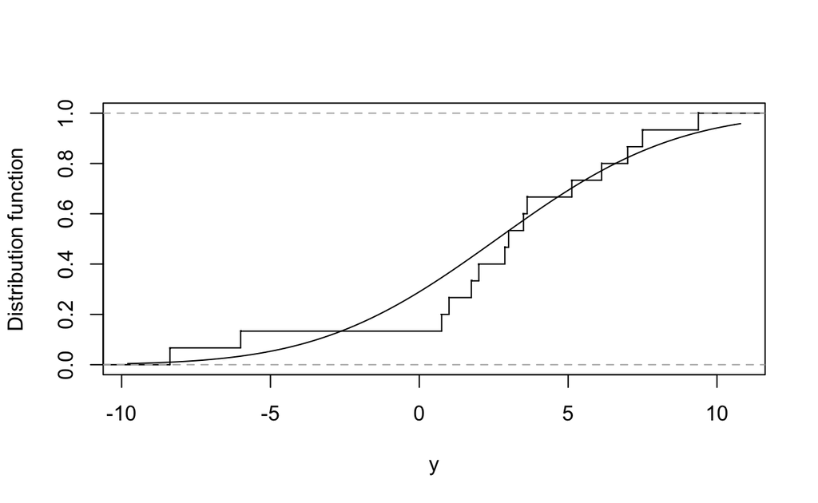

Figure 3: Darwin data: comparison between distribution and empirical distribution

A standard test for $H_0$ is based on the Kolmogorov-Smirnov statistic
$$T=\sup_{y}|\hat{F}(y) - F(y)|$$

```
    One-sample Kolmogorov-Smirnov test

data:  differences
D = 0.21285, p-value = 0.4442
alternative hypothesis: two-sided
```

To compute the $p$-value we can generate $B$ independent sets of data from the null distribution $N(\theta, \tau^2)$, calculating the corresponding statistics $T^{b}$ and
$$p_{\mathrm{obs}}= \frac{1+\sum_{b=1}^{B} I\{ T^b \geq t_{\mathrm{obs}} \}}{1+B}$$

If we generate data from $N(\hat{\theta}, \hat{\tau}^2)$ instead of $N(\theta, \tau^2)$, the resulting inference is only approximate. There is some more refined distribution theory for the Kolmogorov-Smirnov test with estimated parameters, but that is not implemented in the R function `ks.test`.

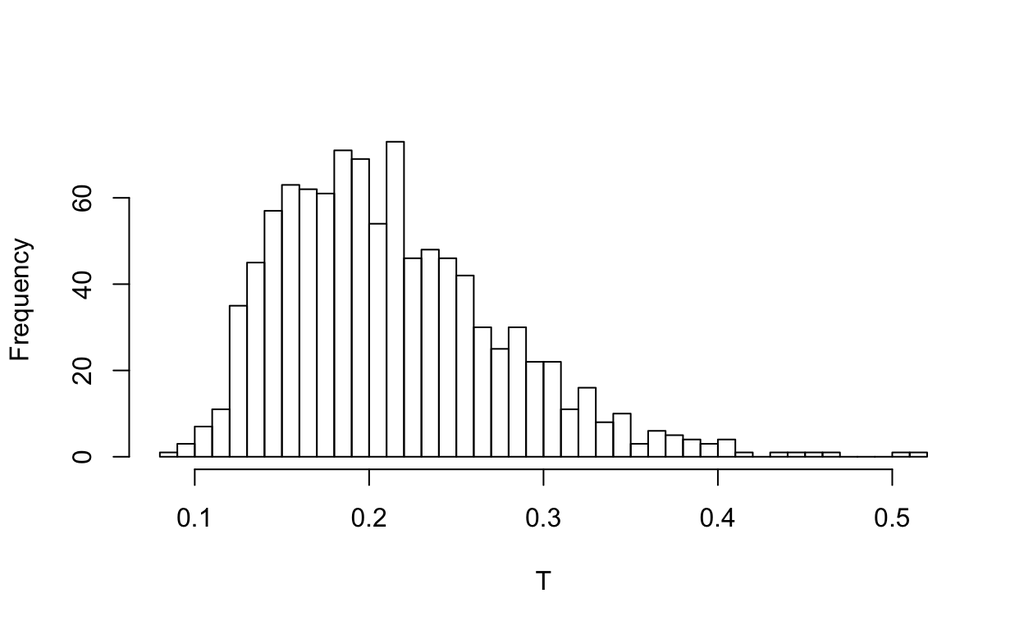

Figure 4: Darwin data: histogram of the null distribution for the Kolgomorov-Smirnov statistic

```
p-value = 0.4475524
```

### Two-decision problem

We supposed that only the null hypothesis is explicitly formulated. We now assume that, in addition to $H_0$, we have an *alternative hypothesis* $H_1$. The choice here lies between only *two decisions*: rejecting or not rejecting the null hypothesis. A decision procedure for such a problem is called a *test* of $H_0$ against $H_1$. By fixing the probability of rejecting $H_0$ when it is true, denoted by $\alpha$, aiming to maximize the probability of rejecting $H_0$ when false. This approach essentially it amounts to setting in advance a threshold for $p_{\mathrm{obs}}$.

Suppose we have data $Y$ distributed according to $\mathrm{P}_{\theta}$ with $\theta \in \Theta$. About $\theta$ we formulate the null hypotheses $H_0: \theta \in \Theta_0$ with $\Theta_0 \subseteq \Theta$. The alternative hypothesis is $H_1: \theta \in \Theta_1$ with $\Theta_1=\Theta\setminus \Theta_0$.

A hypothesis that completely determines the distribution of $Y$ is called *simple*; otherwise is *composite*.

A test $\phi$ assigns to each possible value $y$ of $Y$ one of these two decisions
$$\phi: \mathcal{Y} \mapsto \{0,1\}$$
where 1 denotes the decision of rejecting $H_0$ and 0 denotes the decision of not rejecting $H_0$, and thereby partition the sample space $\mathcal{Y}$ into two complementary regions $\mathcal{Y}_0$ and $\mathcal{Y}_1$.

When performing a test one may arrive at the correct decision, or one may commit one of two errors: rejecting the hypothesis when it is true (*error of the first kind*) or not rejecting it when it is false (*error of the second kind*).

It is required to assign a bound to the probability of incorrectly rejecting $H_0$ when it is true. Thus one selects the *level* $\alpha \in (0,1)$, and impose the condition that
$$\mathrm{P}_{\theta}(\phi(Y)=1) \leq \alpha \quad \forall \, \theta \in \Theta_0$$

Subject to this condition, it is desired to maximize the *power*
$$\mathrm{P}_{\theta}(\phi(Y)=1) \quad \theta \in \Theta_1$$

Considered as a function of $\theta$ for all $\theta \in \Theta$, this probability is called the *power function* of the test and is denoted by $\beta(\theta)$.

The *size* of the test is defined by
$$\sup_{\theta \in \Theta_0} \mathrm{P}_{\theta}(\phi(Y)=1)$$
If $\sup_{\theta \in \Theta_0} \mathrm{P}_{\theta}(\phi(Y)=1)=\alpha$, then we have an (exact) size $\alpha$ test.

Usually for varying $\alpha$, the rejection regions $\mathcal{Y}_1(\alpha)$ and $\mathcal{Y}_1(\alpha')$ are nested in the sense that
$$\mathcal{Y}_1(\alpha) \subset \mathcal{Y}_1(\alpha') \quad \mathrm{if\,\,}\alpha < \alpha'$$

When this is the case, the $p$-value is defined as the smallest significance level at which the hypothesis would be rejected for the given observation:
$$p_{\mathrm{obs}} = \inf\{\alpha\in [0,1]: y \in \mathcal{Y}_1(\alpha)\}$$

# Neyman-Pearson lemma

**Reference**: Davison (2003), Sections 7.3.2, 7.3.3

Let $f_0(y)$ and $f_1(y)$ denote the probability densities of $Y$ under the null and alternative hypotheses, i.e. $H_0:f(y)=f_0(y)$ and $H_1:f(y)=f_1(y)$. Then the Neyman–Pearson lemma states that the most powerful test of size $\alpha$ has critical region
$$\mathcal{Y}_1 = \Big\{ y \in \mathcal{Y}: \frac{f_1(y)}{f_0(y)} \geq t_{\alpha} \Big\}$$
determined by the likelihood ratio.

To explain this, suppose that such a region does exist and let $\mathcal{Y}'_1$ be any other critical region of size $\alpha$ or less:
$$\alpha = \int_{\mathcal{Y}_1} f_0(y)dy \geq \int_{\mathcal{Y}'_1} f_0(y)dy$$
thus
$$\int_{\mathcal{Y}_1 \setminus \mathcal{Y}'_1} f_0(y)dy \geq \int_{\mathcal{Y}'_1 \setminus\mathcal{Y}_1} f_0(y)dy$$
because $\int_{\mathcal{Y}_1} f_0(y)dy = \int_{\mathcal{Y}_1 \setminus \mathcal{Y}'_1} f_0(y)dy + \int_{\mathcal{Y}_1 \cap \mathcal{Y}'_1} f_0(y)dy$

Now, if $y\in \mathcal{Y}_1 \setminus \mathcal{Y}'_1$, then $f_1(y) \geq t_{\alpha}f_0(y)$ while if $y\in \mathcal{Y}'_1 \setminus \mathcal{Y}_1$ then $t_{\alpha}f_0(y) > f_{1}(y)$.

It follows that
$$\frac{1}{t_{\alpha}} \int_{\mathcal{Y}_1 \setminus \mathcal{Y}'_1} f_1(y)dy\geq \int_{\mathcal{Y}_1 \setminus \mathcal{Y}'_1} f_0(y)dy \geq \int_{\mathcal{Y}'_1 \setminus\mathcal{Y}_1} f_0(y)dy \geq \frac{1}{t_{\alpha}} \int_{\mathcal{Y}'_1 \setminus\mathcal{Y}_1} f_1(y)dy$$

Then
$$\int_{\mathcal{Y}_1 } f_1(y)dy \geq \int_{\mathcal{Y}'_1 } f_1(y)dy$$
thus the power of $\mathcal{Y}_1$ is at least that of $\mathcal{Y}'_1$.

It may happen that $H_0$ is simple and the alternative is composite, but that the likelihood ratio critical region is most powerful for each component of the alternative hypothesis. Then $Y$ is said to be *uniformly most powerful*.

### UMP tests

**Reference**: Davison (2003), Section 7.3.2

Let $Y_1,\ldots,Y_n$ be a random sample from $N(\mu,\sigma^2)$ distribution with known $\sigma^2$, and suppose that we are testing $H^{-}_0: \mu \leq \mu_0$ against $H^+_1: \mu > \mu_0$. Suppose we decide to reject $H^-_0$ if $\bar{Y}$ exceed some constant $t_{\alpha}$.

The size of this test is
$$\sup_{\mu\leq \mu_0} \mathrm{P}_\mu(\bar{Y} \geq t_{\alpha}) = \mathrm{P}_{\mu_0}(\bar{Y} \geq t_{\alpha}) = \mathrm{P}_{\mu_0}\left(\frac{\bar{Y}-\mu_0}{\sqrt{\sigma^2/n}} \geq \frac{t_{\alpha} - \mu_0}{\sqrt{\sigma^2/n}}\right) = \Phi\left(\frac{\mu_0 - t_{\alpha}}{\sqrt{\sigma^2/n}}\right)$$

For a test of size $\alpha$, we must choose $t_{\alpha}=\mu_0 + z_{1-\alpha}\frac{\sigma}{\sqrt{n}}$ and the critical region is
$$\mathcal{Y}^+_{1}=\Big\{(y_1,\ldots,y_n): \bar{y} \geq \mu_0 + z_{1-\alpha}\frac{\sigma}{\sqrt{n}} \Big\}$$
For $\mu_1 > \mu_0$, the power of the test is
$$\beta_{\bar{Y}}(\mu_1)=\mathrm{P}_{\mu_1}(\bar{Y} \geq t_{\alpha}) = \Phi(z_{\alpha} + \delta)$$
where $\delta=\sqrt{n}(\frac{\mu_1 - \mu_0}{\sigma})$.

The likelihood ratio for testing $\mu=\mu_0$ against $\mu=\mu_1$ is
$$\frac{f_1(Y)}{f_0(Y)} = \exp\Big[\frac{1}{2\sigma^2}(2n\bar{Y}(\mu_1-\mu_0)- \mu_1^2 + \mu_0^2)\Big]$$
If $\mu_1 >\mu_0$, this is monotone increasing in $\bar{Y}$, and so the critical region rejects $H_0$ when $\bar{Y} \geq t_{\alpha}$. It follows that this test is most powerful for any $\mu_1> \mu_0$ and so is *uniformly most powerful* (UMP).

Likewise, the test defined by the critical region
$$\mathcal{Y}^-_{1}=\Big\{(y_1,\ldots,y_n): \bar{y} \leq \mu_0 + z_{\alpha}\frac{\sigma}{\sqrt{n}} \Big\}$$
is UMP for testing $H_0^+: \mu\geq \mu_0$ against $H_1^-: \mu\leq \mu_0$.

Of course, the sign test has lower power than the UMP test for testing $H^{-}_0: \mu \leq \mu_0$ against $H^+_1: \mu > \mu_0$. Its test statistic is $S=\sum_{i=1}^{n}I\{Y_i > \mu_0\}$, which gives the critical region
$$\mathcal{Y}'^+_{1}=\Big\{(y_1,\ldots,y_n): \sum_{i=1}^{n}I\{Y_i > \mu_0\} \geq \frac{n}{2} - z_{\alpha}\frac{\sqrt{n}}{2} \Big\}$$
by using a normal approximation.

We have
$$\mathrm{P}_{\mu_1}(Y_i \geq \mu_0) = \mathrm{P}_{\mu_1}\Big(\frac{Y_i - \mu_1}{\sigma} \geq \frac{\mu_0 - \mu_1}{\sigma}\Big) = \Phi\Big(\frac{\delta}{\sqrt{n}}\Big)$$
Under $H_1$, $S$ is approximately normal with mean $\mathrm{E}_1(S) = n \Phi(\delta/\sqrt{n})$ and variance $\mathrm{Var}_1(S) = n\Phi(\delta/\sqrt{n})(1-\Phi(\delta/\sqrt{n}))$.

Then
$$\mathrm{P}_{\mu_1}\Big(S \geq s_{\alpha} \Big)\approx \mathrm{P}_{\mu_1}\Big(N(0,1) \geq \frac{s_{\alpha} - \mathrm{E}_1(S)}{\sqrt{\mathrm{Var}_1(S)}} \Big)$$
where $s_{\alpha}= \frac{n}{2} - z_{\alpha}\frac{\sqrt{n}}{2}$. For $n$ large,
$$\Phi(\delta n^{-1/2}) \approx \Phi(0) + \Phi'(0)(\delta n^{-1/2}) = \frac{1}{2} + \frac{\delta\phi(0)}{\sqrt{n}} = \frac{1}{2} + \frac{\delta}{\sqrt{2\pi n}}$$
and after simplifying,
$$\beta_S(\mu_1)=\mathrm{P}_{\mu_1}(S \geq s_\alpha) \approx \Phi\Big(z_\alpha + \delta\sqrt{\frac{2}{\pi}}\Big)$$

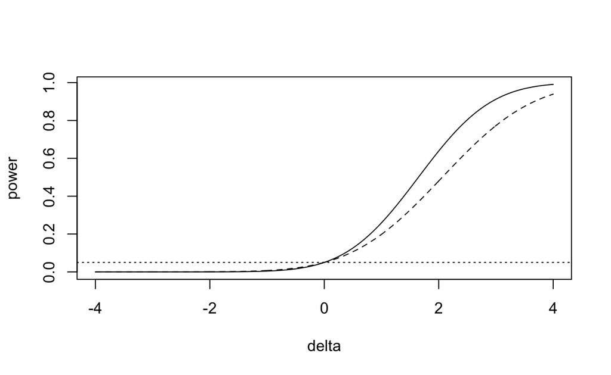

Figure 5: Power functions of UMP and sign test

Suppose now that we wish to test $H_0: \mu = \mu_0$ against $H_1: \mu \neq \mu_0$.

The critical region
$$\mathcal{Y}_{1}= \mathcal{Y}^{-}_{1} \cup \mathcal{Y}^{+}_{1}$$
has size $2\alpha$, and no uniformly more powerful test exists for the two-sided alternative.

A test $\phi$ of $H_0:\theta \in \Theta_0$ against $H_1: \theta \in \Theta_1$ is *unbiased* of size $\alpha$ if $\sup_{\theta \in \Theta_0}\mathrm{P}_{\theta}(\phi(Y)=1)=\alpha$ and $\mathrm{P}_{\theta}(\phi(Y)=1)\geq\alpha$ for all $\theta \in \Theta_1$. A test which is uniformly most powerful amongst the class of all unbiased tests is *uniformly most powerful unbiased* (UMPU).

It can be proved that the test defined by $\mathcal{Y}_{1}= \mathcal{Y}^{-}_{1} \cup \mathcal{Y}^{+}_{1}$ is UMPU.

### Hotelling’s $T^2$ test

Let $Y_1,\ldots,Y_n$ be a random sample from the $m$-variate normal distribution $N_m(\mu,\Sigma)$, and suppose that we are testing $H_0: \mu=\mu_0$ against $H_1: \mu \neq \mu_0$.

If $\Sigma$ is known, the likelihood ratio test statistic is
$$T^2 = n(\bar{Y} - \mu_0)'\Sigma^{-1}(\bar{Y} - \mu_0)$$
which follows the Chi-squared distribution $\chi^2_m$ under $H_0$.

If $\Sigma$ is unknown, the Hotelling $T^2$ statistic is
$$T^2 = n(\bar{Y} - \mu_0)'S^{-1}(\bar{Y} - \mu_0)$$
where $S = \frac{1}{n-1}\sum_{i=1}^{n}(Y_i - \bar{Y})(Y_i - \bar{Y})'$. Under $H_0$, $T^2$ follows a Hotelling’s T-squared distribution
$$T^2_{m,n-1} = \frac{m(n-1)}{n-m} F_{m,n-m}$$
where $F_{m,n-m}$ is the F-distribution with parameters $m$ and $n-m$.

The Hotelling $T^2$ statistic is a generalization of Student $t$ statistic, i.e. for $m=1$, $T^2 = (t)^2$.

The $T^2$ statistic is invariant to full rank linear transformations
$$X = AY + b$$
with $\underset{m\times m}{A}$ non-singular.

No UMP test exists for this problem. It can be proved that the Hotelling $T^2$ test is the most powerful test in the class of tests that are invariate to full rank linear transformations (UMPI).

### Testing equivalence

Let $Y_1,\ldots,Y_n$ be a random sample from $N(\mu,1)$, and suppose that we are testing $H_0: \mu \in (-\infty,-\Delta] \cup [\Delta,\infty)$ against $H_1: \mu \in (-\Delta,\Delta)$ for some pre-specified $\Delta >0$.

Consider the test statistic
$$T= n\bar{Y}^2 \sim \chi^2_{1,n\mu^2}$$
which rejects for small values, where $\chi^2_{\nu,\lambda}$ is a non-central Chi-squared distribution with $\nu$ degree of freedom and noncentrality parameter $\lambda$.

Because
$$\sup_{\mu \in (-\infty,-\Delta] \cup [\Delta,\infty)} \mathrm{P}_\mu(T \leq t_{\alpha}) = \mathrm{P}(\chi^2_{1,n\Delta^2} \leq t_{\alpha})$$

the critical region of size $\alpha$ is given by

$$\mathcal{Y}_1 = \{(y_1,\ldots,y_n): T \leq t_{\alpha} \} = \{(y_1,\ldots,y_n):-\sqrt{t_{\alpha}/n} \leq \bar{y} \leq \sqrt{t_{\alpha}/n} \}$$

where $t_{\alpha}$ is the $\alpha$ quantile of $\chi^2_{1,n\Delta^2}$.

It can be proved that this test is UMP.

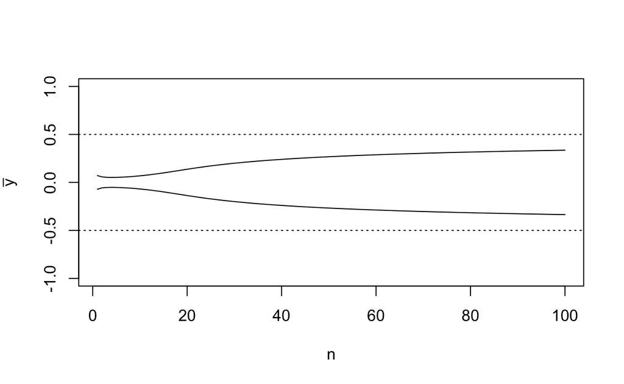

Figure 6: Critical region of testing equivalence with Delta = 1/2 at 5% level

Let $Y_1,\ldots,Y_n$ i.i.d. $N(\mu,\sigma^2)$ and suppose we want to test $H_0: \frac{\mu}{\sigma} \in (-\infty,-\Delta] \cup [\Delta,\infty)$ against
$H_1: \frac{\mu}{\sigma} \in (-\Delta,\Delta)$. Consider the squared $t$ test statistic
$$T = \frac{n\bar{Y}^2}{S^2} \sim F_{1,n-1,n\frac{\mu^2}{\sigma^2}}$$
which rejects for small values, where $F_{\nu_1,\nu_2,\lambda}$ is a non-central F distribution with $\nu_1$ and $\nu_2$ degree2 of freedom and noncentrality parameter $\lambda$.

The $p$-value of the test is
$$p_{\mathrm{obs}} = \mathrm{P}_{\Delta}(T \leq t_{\mathrm{obs}}) = \mathrm{P}(F_{1,n-1,n\Delta^2} \leq t_{\mathrm{obs}})$$

For the Darwin data we take $\Delta=1/5$, which is a conventional value for an effect of small magnitude, and we obtain a $p$-value of

```
0.7229673
```

### Similar tests

Suppose that $\theta = (\psi,\lambda)$ where $\psi \in \Psi$ is called the *parameter of interest* and $\lambda \in \Lambda$ is called *nuisance parameter*, with $\Theta = \Psi \times \Lambda$.

Usually the null hypothesis impose the constraint $\psi = \psi_0$ but puts no restriction on $\lambda$. The $p$-value may be then written

$$\mathrm{P}_0(T \geq t_{\mathrm{obs}})=\mathrm{P}(T \geq t_{\mathrm{obs}}; \psi_0,\lambda) = \int_{y: t(y) \geq t_{\mathrm{obs}}} f(y; \psi_0,\lambda)dy$$

which depends on $\lambda$.

Sometimes a critical region $\mathcal{Y}_1$ of size $\alpha$ can be found such that

$$\mathrm{P}(Y \in \mathcal{Y}_1; \psi_0,\lambda) = \alpha \quad \forall \lambda \in \Lambda$$

Such a $\mathcal{Y}_1$ is called a *similar region*; it is similar to the sample space, which satisfies this equation with $\alpha = 1$. A test whose critical regions are similar is called a *similar test*. One approach to find similar test is the use of conditioning.

When there is a minimal sufficient statistic $S_0$ for the unknown $\lambda$ in a null distribution, it can be removed by conditioning, giving $p$-value

$$p_{\mathrm{obs}} = \mathrm{P}_0(T \geq t_{\mathrm{obs}} | S_0;\psi_0)= \int_{y: t(y) \geq t_{\mathrm{obs}}} f(y| s_0; \psi_0)dy$$

which is independent of $\lambda$ by sufficiency of $S_0$.

### Permutation test

Let $Y_1,\ldots,Y_m$ and $Y_{m+1},\ldots, Y_n$ be independent random samples with densities $g(y)$ and $g(y-\theta)$ where $g$ is unknown. Suppose we wish to test the null hypothesis $\theta=0$.

Under the null hypothesis, $Y_1,\ldots,Y_n$ form a random sample with unknown density $g$, and the set of ordered statistics $Y_{(1)},\ldots,Y_{(n)}$ is a minimal sufficient statistic. The conditional distribution of $Y_1,\ldots,Y_n$ given the observed values $y_{(1)},\ldots,y_{(n)}$ of the ordered statistics puts equal mass on each of the $n!$ permutations of $y_{1},\ldots,y_{n}$, so the $p$-value is
$$p_{\mathrm{obs}} = \mathrm{P}_0(T \geq t_{\mathrm{obs}} | Y_{(1)},\ldots,Y_{(n)}) = \frac{1}{n!} \sum I\{t(y_{\mathrm{perm}}) \geq t_{\mathrm{obs}} \}$$
where the sum is over all permutations $y_{\mathrm{perm}} = (y_{\pi(1)}, \ldots,y_{\pi(n)})$ of $y_1,\ldots,y_n$.

# Duality with confidence intervals

**Reference**: Davison (2003), Section 7.3.4

If the density of $Y$ depends on a scalar parameter $\theta$, we define an *upper bound* for $\theta$ at confidence level $1-\alpha$ to be a function $\bar{\theta}_{\alpha} = \bar{\theta}_{\alpha}(Y)$ such that
$$\mathrm{P}_{\theta}(\theta \leq \bar{\theta}_{\alpha})\geq 1-\alpha \qquad \forall\, \theta \in \Theta$$

Lower confidence bounds may be defined analogously. An equi-tailed $(1-2\alpha)$ confidence interval for $\theta$ is $[\underline{\theta}_{\alpha}, \bar{\theta}_{\alpha}]$

There is a link between tests and the construction of confidence intervals. For each $\theta_0 \in \Theta$, let $\mathcal{Y}_0(\theta_0)$ be the acceptance region of a test of size $\alpha$ for testing $\theta=\theta_0$. The set of values of $\theta$ not rejected by the test
$$S(Y) = \{\theta \in \Theta: Y \in \mathcal{Y}_0(\theta)\}$$
contains the true parameter with probability at least $1-\alpha$.

By definition of $S(Y)$, $\theta \in S(Y)$ if and only if $Y \in \mathcal{Y}_0(\theta)$, and hence
$$\mathrm{P}_{\theta}(\theta \in S(Y)) = \mathrm{P}_{\theta}(Y \in \mathcal{Y}_0(\theta)) \geq 1-\alpha \qquad \forall\,\,\theta \in \Theta$$

### Confidence intervals for nonpivotal quantities

**Reference**: Kelley (2007)

Although confidence intervals for the mean $\mu$ and the variance $\sigma^2$ of a Gaussian distribution are well known, the confidence interval for the standardized mean
$$\theta = \frac{\mu}{\sigma}$$
is less known. Consider
$$\sqrt{n}\hat{\theta} = \sqrt{n} \frac{\bar{Y}}{S} \sim t_{n-1, \sqrt{n}\theta}$$
where $\bar{Y}$ is the sample mean and $S^2$ is the unbiased estimator of the variance based on a random sample of size $n$.

A confidence interval for $\theta$ with level $1-2\alpha$ is given by $[\underline{\theta}_{\alpha}, \overline{\theta}_{\alpha}]$ with $\underline{\theta}_{\alpha}$ such that $\displaystyle T_{n-1,\frac{\underline{\theta}_{\alpha}}{\sqrt{n}}}(\sqrt{n}\hat{\theta}_{\mathrm{obs}}) = 1-\alpha$ and $\overline{\theta}_{\alpha}$ such that $\displaystyle T_{n-1,\frac{\overline{\theta}_{\alpha}}{\sqrt{n}}}(\sqrt{n}\hat{\theta}_{\mathrm{obs}}) = \alpha$, respectively, where $T_{\nu,\lambda}(t)$ denotes the cumulative distribution function evaluated at $t$ of a non-central Student’s t distribution with $\nu$ degrees of freedom and non-centrality parameter $\lambda$.

Davison, Anthony Christopher. 2003. *Statistical Models*. Vol. 11. Cambridge University Press.

Kelley, Ken. 2007. “Confidence Intervals for Standardized Effect Sizes: Theory, Application, and Implementation.” *Journal of Statistical Software* 20: 1–24.